# Grammar of Graphic

# 4) Facets

`facet_grid(rows ~ columns)`: create several views Really useful when we have several variables to plot, especially ordinal.

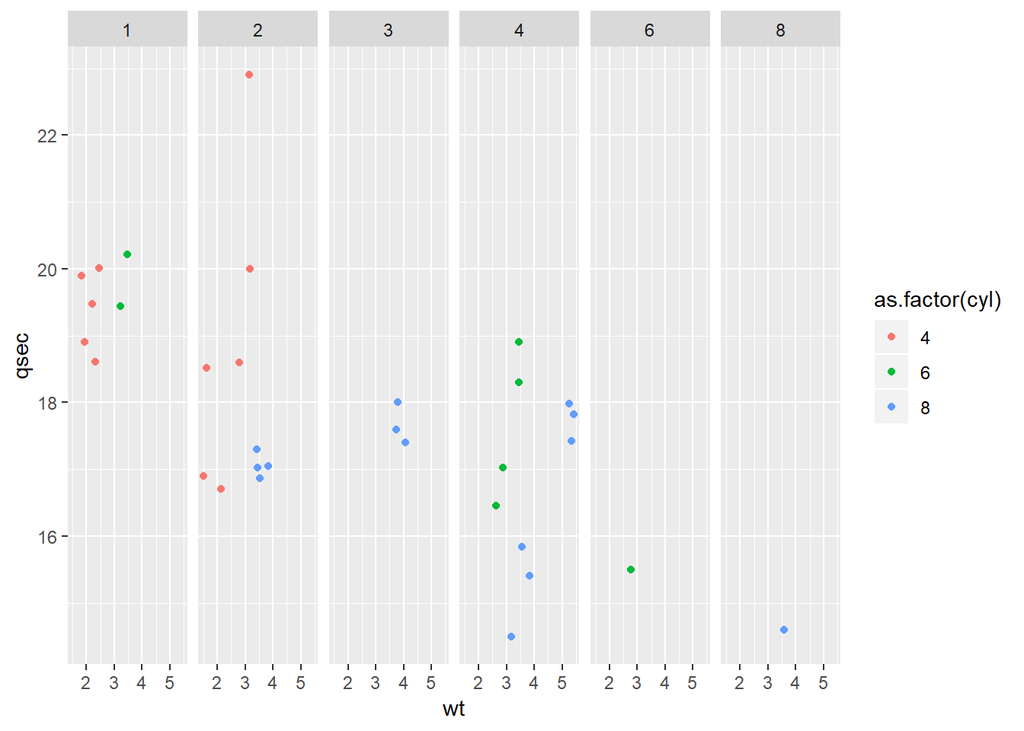

```r
ggplot(mtcars,aes(x=wt,
                  y=qsec,
                  col=as.factor(cyl)))+
  geom_point()+
  facet_grid(.~as.factor(carb))
```

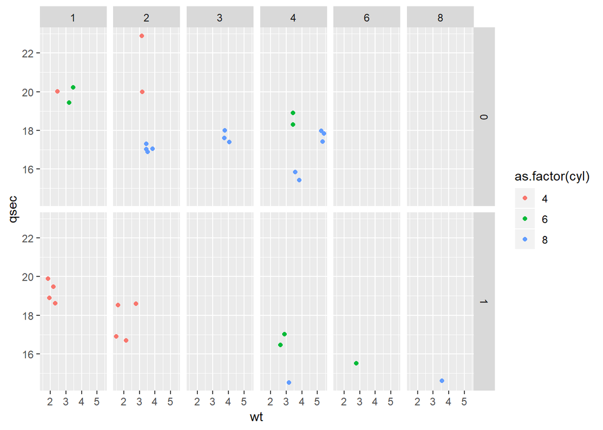

```r
ggplot(mtcars,aes(x=wt,
                  y=qsec,
                  col=as.factor(cyl)))+
  geom_point()+
  facet_grid(as.factor(am)~as.factor(carb))
```

If you want to drop some levels (no observations): `space="free_y"`

If you would like to have adaptative scale: `scale="free_y"`

# 5) Statistics

We add a linear regression.

stat_functions can be closed to geom. There is no differences between `geom_smooth(method = "lm", se = F, col = "red")` and `stat_smooth(method = "lm", se = F, col = "red")`

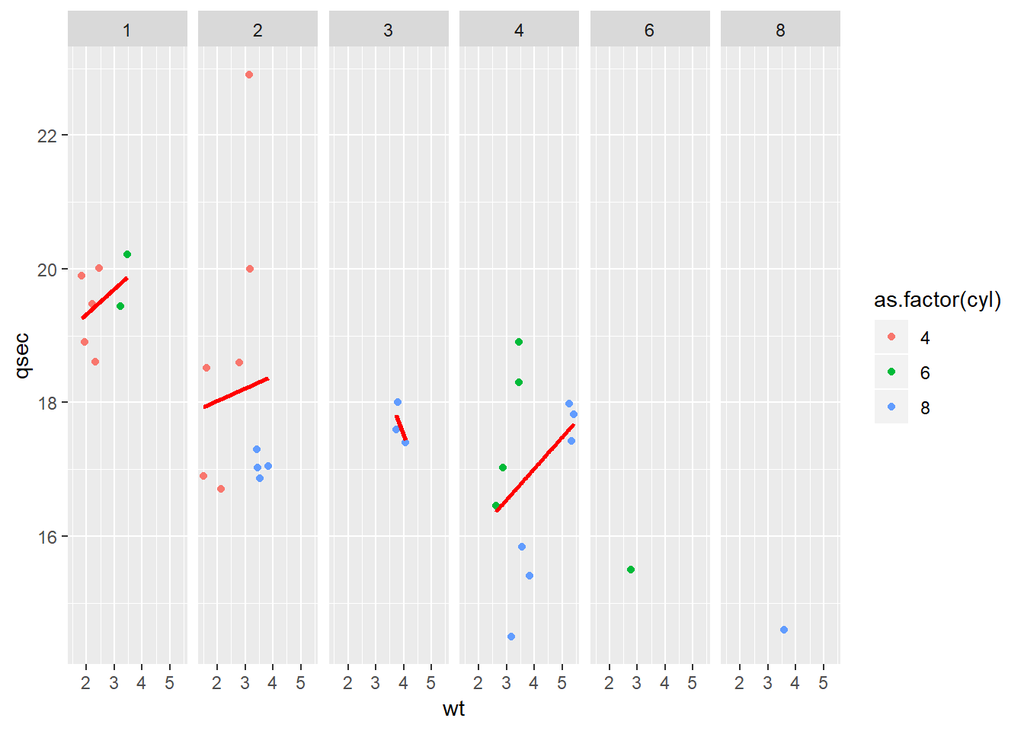

```r
ggplot(mtcars,aes(x=wt,
                  y=qsec,
                  col=as.factor(cyl)))+
  geom_point()+
  facet_grid(.~as.factor(carb))+
  stat_smooth(method = "lm", se = F, col = "red")
```

Several statistics:

```
## Smoothing formula not specified. Using: y ~ x
```

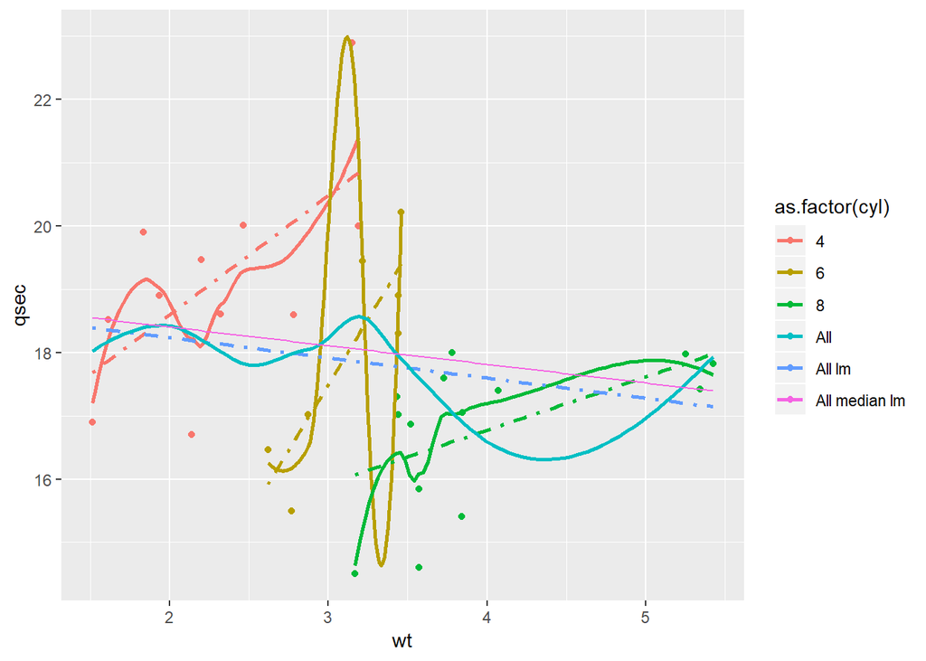

```r
ggplot(mtcars,aes(x=wt,
                  y=qsec,
                  col=as.factor(cyl)))+
  geom_point()+
  stat_smooth(method = "loess", se = F)+
  stat_smooth(method = "lm", se = F,linetype="dotdash")+
  stat_smooth(method = "lm", se = F,linetype="dotdash",aes(group=1,col="All lm"))+
  stat_smooth(method = "loess",
              se = F,
              aes(group=1,col="All"),
              span=0.7)+
  stat_quantile(quantiles = 0.5,aes(group=1,col="All median lm"))
```

# 6) Coordinates

Note that we find the scale_function that enables us to access to the aesthetics.

- `scale_y_continuous`
- `scale_x_discrete`
- `scale_color_discrete`
- `scale_fill_continuous`
- `scale_shape...`
- `scale_linetype...`

Useful to zoom on the plot. * `xlim()` * `scale_x_continuous` * `coordcartesian(xlim=)`

Aspect ratio, by default 1:1. Beware when you change it, it can be very deceiptful ! * `coord_fixed()` * `coord_equal()`

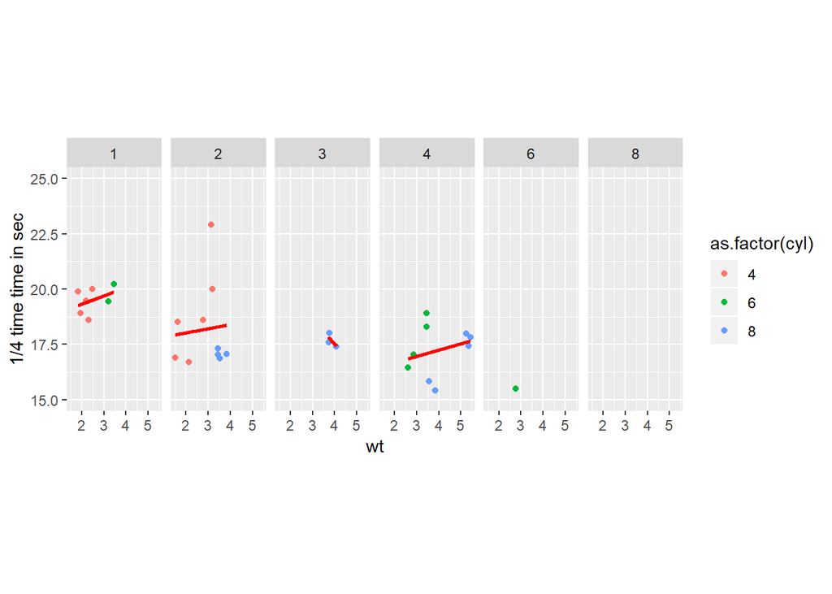

```r
ggplot(mtcars,aes(x=wt,
                  y=qsec,
                  col=as.factor(cyl)))+
  geom_point()+
  facet_grid(.~as.factor(carb))+
  stat_smooth(method = "lm",
              se = F,
              col = "red")+
  scale_y_continuous("1/4 time time in sec",
                     limits=c(15,25))+
  coord_equal()
```

Use polar coordinate to create pie chart

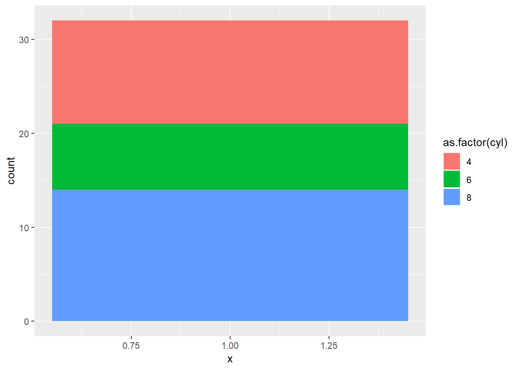

```r
ggplot(mtcars, aes(x = 1, fill = as.factor(cyl)))+
  geom_bar()
```

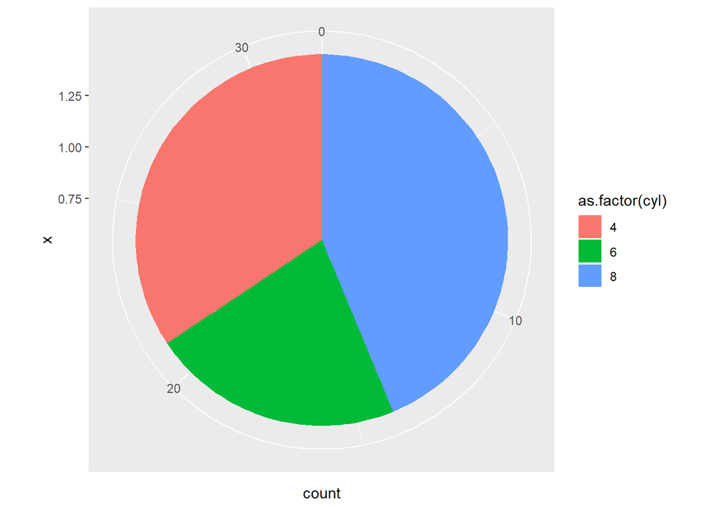

```r
ggplot(mtcars, aes(x = 1, fill = as.factor(cyl)))+
  geom_bar()+
  coord_polar(theta = "y")
```

# 7) Themes

Themes control all the non-ink data: all the visual elements that are not part of the data.

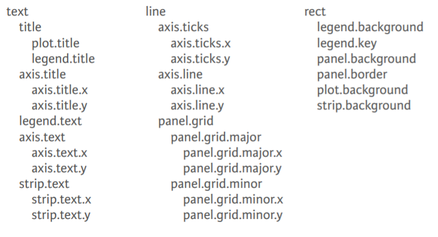

Elements of theme

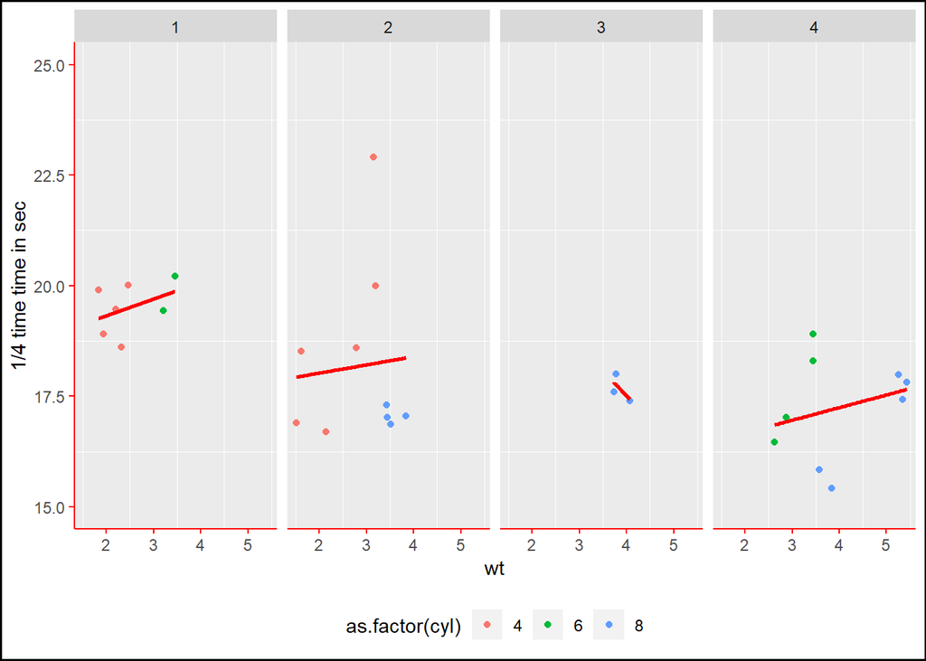

```r
ggplot(mtcars%>%filter(carb<6 & qsec>15),aes(x=wt,
                  y=qsec,
                  col=as.factor(cyl)))+
  geom_point()+
  facet_grid(.~as.factor(carb))+
  stat_smooth(method = "lm",
              se = F,
              col = "red")+
  scale_y_continuous("1/4 time time in sec",
                     limits=c(15,25))+
  theme(plot.background =element_rect(fill = "white",color="black",size=1),
        panel.grid.major = element_blank(),
        axis.line=element_line(color="red"),
        axis.ticks=element_line(color="red"),
        legend.position = "bottom")
```

Use a pre-defined theme

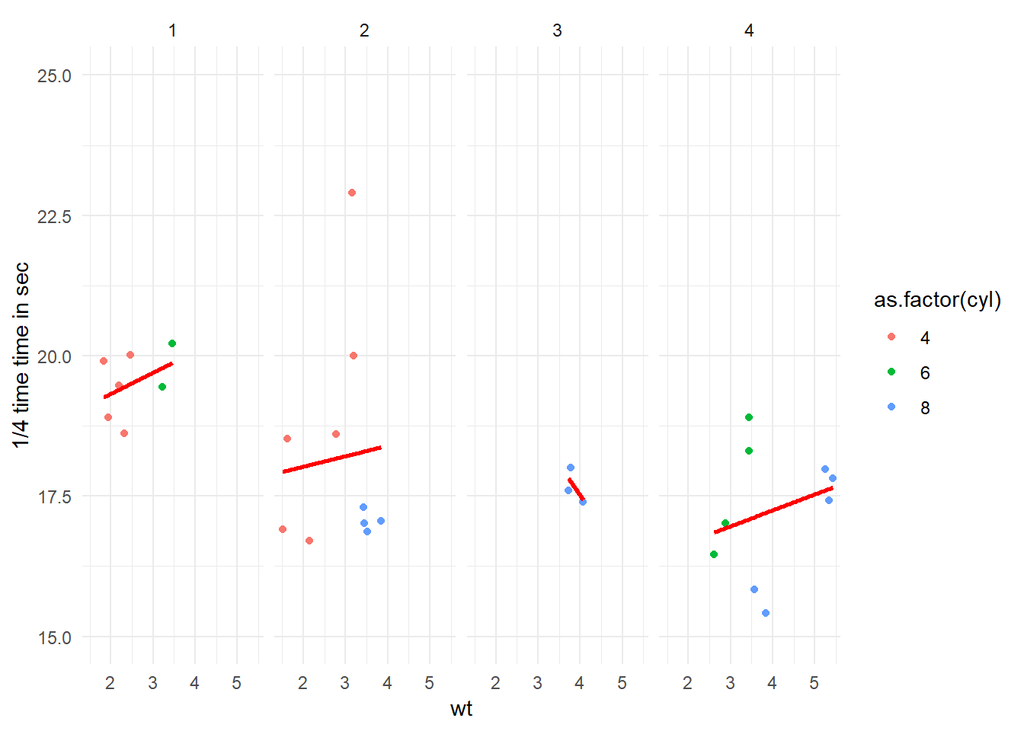

```r
ggplot(mtcars%>%filter(carb<6 & qsec>15),aes(x=wt,
                  y=qsec,
                  col=as.factor(cyl)))+
  geom_point()+
  facet_grid(.~as.factor(carb))+
  stat_smooth(method = "lm",
              se = F,
              col = "red")+
  scale_y_continuous("1/4 time time in sec",
                     limits=c(15,25))+
  theme_minimal()
```

# Conclusion

Building a graph is manipulating the grammar of graphic ! s

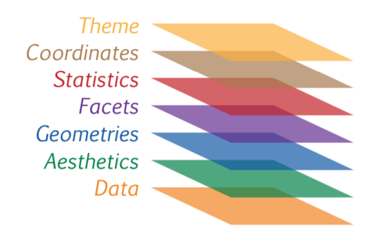

Layers of Grammar